# Chemical Structures of PCBs congeners

5.7

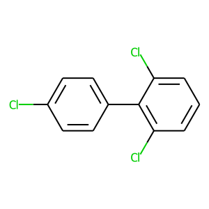

2,3',4'-Trichlorobiphenyl

38444-86-9

C12H7Cl3

5.9

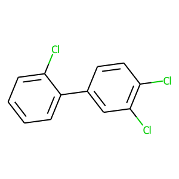

2,3',5'-Trichlorobiphenyl

37680-68-5

C12H7Cl3

5.6

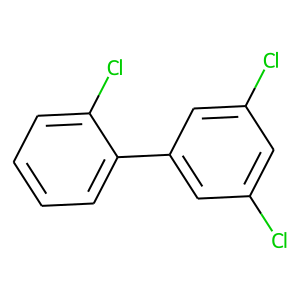

3,3',4-Trichlorobiphenyl

37680-69-6

C12H7Cl3

5.9

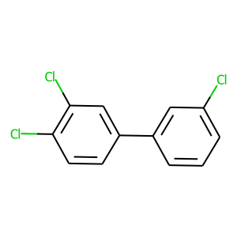

3,3',5-Trichlorobiphenyl

38444-87-0

C12H7Cl3

5.8

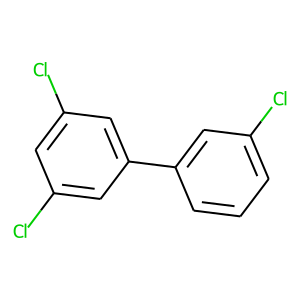

3,4,4'-Trichlorobiphenyl

38444-90-5

C12H7Cl3

5.9

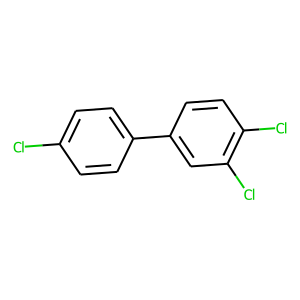

3,4,5-Trichlorobiphenyl

53555-66-1

C12H7Cl3

6.0

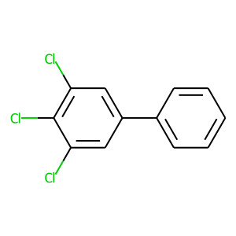

3,4',5-Trichlorobiphenyl

38444-88-1

C12H7Cl3

5.4

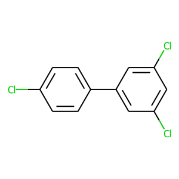

2,2',3,3'-Tetrachlorobiphenyl

38444-93-8

C12H6Cl4

6.2

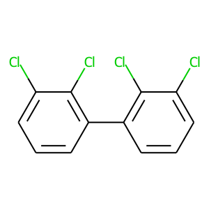

2,2',3,4-Tetrachlorobiphenyl

52663-59-9

C12H6Cl4

6.1

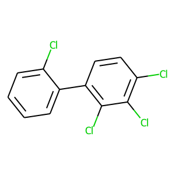

2,2',3,4'-Tetrachlorobiphenyl

36559-22-5

C12H6Cl4

6.0

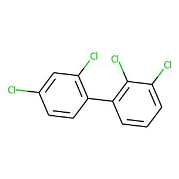

2,2',3,5-Tetrachlorobiphenyl

70362-46-8

C12H6Cl4

5.8

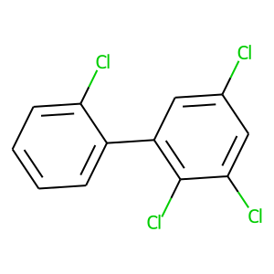

2,2',3,5'-Tetrachlorobiphenyl

41464-39-5

C12H6Cl4

5.8

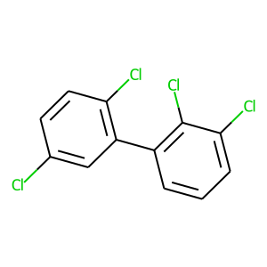

2,2',3,6-Tetrachlorobiphenyl

70362-45-7

C12H6Cl4

5.4

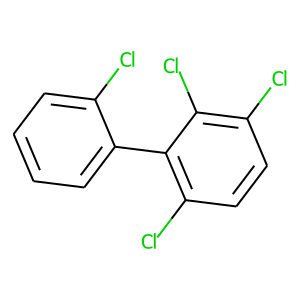

2,2',3,6'-Tetrachlorobiphenyl

41464-47-5

C12H6Cl4

5.4

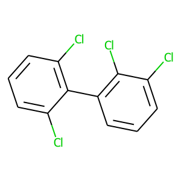

2,2',4,4'-Tetrachlorobiphenyl

2437-79-8

C12H6Cl4

6.3

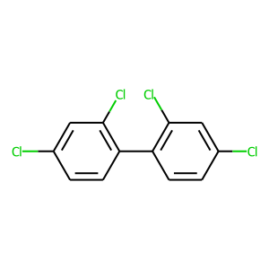

2,2',4,5-Tetrachlorobiphenyl

70362-47-9

C12H6Cl4

6.6

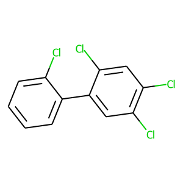

2,2',4,5'-Tetrachlorobiphenyl

41464-40-8

C12H6Cl4

6.4

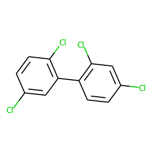

2,2',4,6-Tetrachlorobiphenyl

62796-65-0

C12H6Cl4

6.1

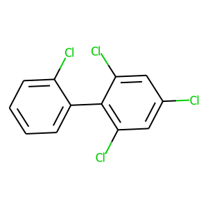

2,2',4,6'-Tetrachlorobiphenyl

68194-04-7

C12H6Cl4

6.1

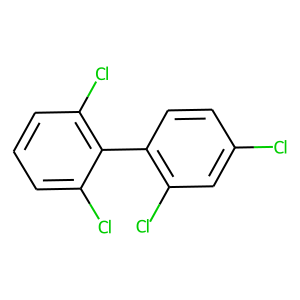

2,2',5,5'-Tetrachlorobiphenyl

35693-99-3

C12H6Cl4

6.1

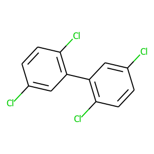

2,2',5,6'-Tetrachlorobiphenyl

41464-41-9

C12H6Cl4

5.6

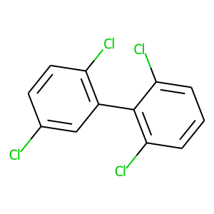

2,2',6,6'-Tetrachlorobiphenyl

15968-05-5

C12H6Cl4

5.9

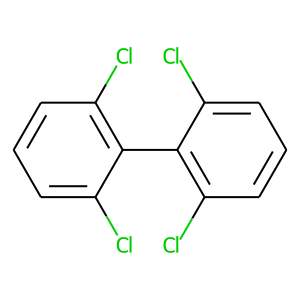

2,3,3',4-Tetrachlorobiphenyl

74338-24-2

C12H6Cl4

6.2

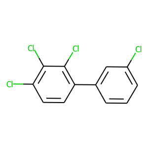

2,3,3',4'-Tetrachlorobiphenyl

41464-43-1

C12H6Cl4

6.0

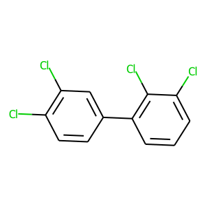

2,3,3',5-Tetrachlorobiphenyl

70424-67-8

C12H6Cl4

6.2

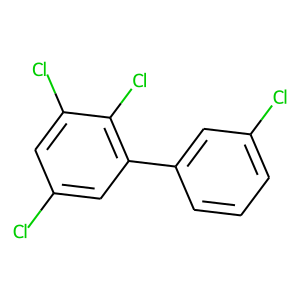

2,3,3',5'-Tetrachlorobiphenyl

41464-49-7

C12H6Cl4

6.2

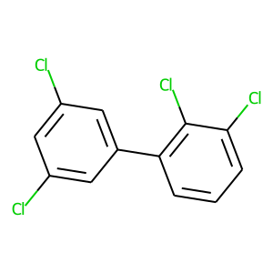

2,3,3',6-Tetrachlorobiphenyl

74472-33-6

C12H6Cl4

6.3

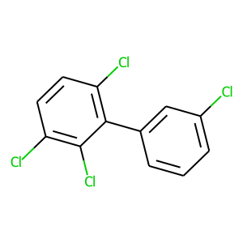

2,3,4,4'-Tetrachlorobiphenyl

33025-41-1

C12H6Cl4

6.5

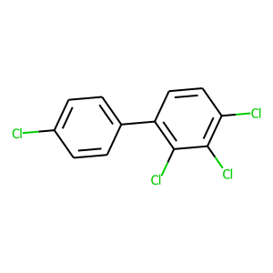

2,3,4,5-Tetrachlorobiphenyl

33284-53-6

C12H6Cl4

6.4

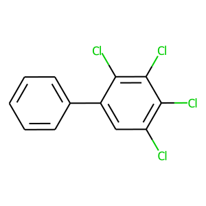

2,3,4,6-Tetrachlorobiphenyl

54230-22-7

C12H6Cl4

5.8

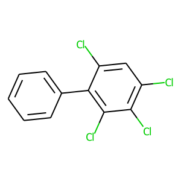

2,3,4',5-Tetrachlorobiphenyl

74472-34-7

C12H6Cl4

6.2

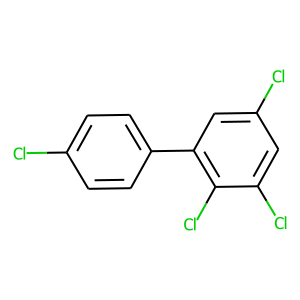

2,3,4',6-Tetrachlorobiphenyl

52663-58-8

C12H6Cl4

6.3

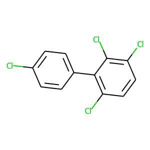

2,3,5,6-Tetrachlorobiphenyl

33284-54-7

C12H6Cl4

5.9

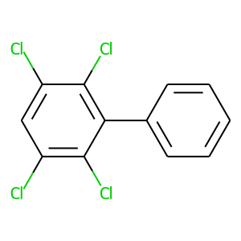

2,3',4,4'-Tetrachlorobiphenyl

32598-10-0

C12H6Cl4

6.3

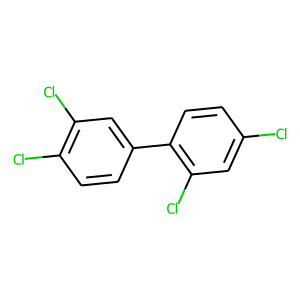

2,3',4,5-Tetrachlorobiphenyl

73575-53-8

C12H6Cl4

6.5

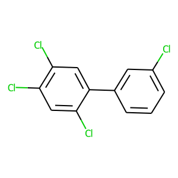

2,3',4,5'-Tetrachlorobiphenyl

73575-52-7

C12H6Cl4